# Monte-Carlo Methods

**Jimmy Pulido-Arias**

**Chonnam National University**

> **Access the slides online:**

[figure not shown]

### https://jiapulidoar.github.io/2022/RL/montecarlo.html

### Notebook In Colab!

[figure not shown]

Access notebook in Google Colab:

### https://colab.research.google.com/drive/1SXDvM2ZjaOTn67KIkIpAIBSdPGXAfoBE?usp=sharing

## Definition

Apply repeated random sampling to obtain numerical results for difficult or otherwise Impossible problems

General approach:

1. Define a domain of possible inputs
2. Generate inputs randomly from a probability distribution over the domain
3. Perform a deterministic computation on the inputs
4. Aggregate (e.g. average) the results

### Approximating the value of π.

Monte Carlo method applied to approximating the value of π.

Consider a quadrant (circular sector) inscribed in a unit square. Given that the ratio of their areas is $ \pi / 4$ , the value of π can be approximated using a Monte Carlo method.

[figure not shown]

```
interactive(children=(IntSlider(value=5000, description='N', max=10000, min=1), Output()), _dom_classes=('widg…
```

```
pi value: 3.1552
```

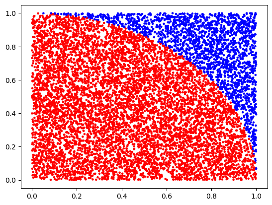

```python
#Estimating pi using Monte Carlo
def pi_MC(N):
    circle = 0
    X, Y = ([], [])
    R = []
    for i in range(N):
        x, y = (random(), random())
        X.append(x)
        Y.append(y)
        r = sqrt(x**2 +  y**2)
        R.append(r < 1 )
        if r <1: circle += 1
    plt.scatter(X,Y, c = R, s = 5, cmap="bwr")
    print("pi value: {}".format( circle/N * 4 ))
    return()

interact(pi_MC, N=(1,10000,1));

pi_MC(10000)
plt.show()
```

### Monte Carlo - Reinforcemnt Learning

> Monte Carlo methods require only experience—sample

sequences of states, actions, and rewards from actual or simulated interaction with an environment.

Monte Carlo reinforcement learning learns from episodes of experience:

1. Empirical Risk minimization
2. Model Free (No knowledge of MDP transitions/rewards)
3. Learns from complete episodes (A complete game until reaching goal)
4. One simple idea: the value function = the empirical mean **Return**

**Example of an Episode**

[figure not shown]

## Monte Carlo Prediction:

We sample episodes from experience following policy $\pi$

$$ S_0, A_0, R_1, S_1, A_1,...,S_{T-1}, A_{T-1}, R_T \sim \pi$$

Loop for each step of episode, $t = T -1, T-2, ..., 0$

$$ G \leftarrow \gamma G + R_{t+1}$$

In other words:

$$ G = \gamma^{T-1} R _{T} +...+ \gamma R_{2} + R_{1} $$

Value function as the expected return :

$$ V_{\pi}(s) = E_{\pi}[G_t | S_t = s]$$

> We usally use an empirical mean instead of the expected return.

### First-visit MC prediction

[figure not shown]

### Prediction with incremental updates

#### Incremental means

Reinforcemt alforithms use something calles incremental means, where $\mu_1, \mu_2,...$ from a sequence

$$ \mu_k = \dfrac{1}{k} \sum_{j=1}^{k} x_j $$$$ = \dfrac{1}{k} ( x_k + \sum_{j=1}^{k-1} x_j )$$$$ = \dfrac{1}{k} ( x_k + (k-1) \mu_k -1 )$$$$ = \mu_{k-1} + \dfrac{1}{k}(x_k - \mu_{k-1}) $$

All these together: sample episodes from experience following policy $\pi$

$$ S_0, A_0, R_1, S_1, A_1,...,S_{T-1}, A_{T-1}, R_T \sim \pi$$

every time we visit a state, we’re going to increase a visit counter, then we will use our running mean:

$$ N(S_t) \leftarrow N(S_t) + 1 $$$$ V(S_t) \leftarrow V(S_t) + \dfrac{1}{N(S_t)} (G_t - V(St)) $$

### Catching Q values

> Store value in an numpy array e.x.: *n_states X n_actions* size Matrix

Greedy policy improvement over Q(s, a) is model-free:

$$ \pi'(s) = arg maxQ(s,a), a\in A$$

[figure not shown]

### Alorithm: Greedy MC that will get stuck

```
Q = np.zeros([n_states, n_actions])
n_visits = np.zeros([n_states, n_actions])

for episode in range(num_episodes):
    s = env.reset(), done = False, result_list = []
    while not done:
    → a = np.argmax(Q[s, :])
        s’, reward, done, _ = env.step(a)
        results_list.append((s, a))
        result_sum += reward
        s = s’
    for (s, a) in results_list:
        n_visits[s, a] += 1.0
        α = 1.0 / n_visits[s, a]
        Q[s, a] += α ∗ (result_sum − Q[s, a])
```

### Alorithm: Greedy MC that will get stuck

[figure not shown]

## ϵ -greedy exploration

## ϵ -greedy exploration

The simplest idea to avoid local minima is:

- choose a random action with probability $\epsilon$
- choose the action greedily with probability $1-\epsilon$
- where all m actions are tied with non-zero probability

So we have the updated policy:

$$ \pi(\alpha | s) = \begin{cases} \epsilon/m + 1 - \epsilon & if a^* = max_{a\in A} Q(s,a) \\ \epsilon/m & otherwise \end{cases} $$

> Proof of converge in 5.1 of Reference [1]

## ϵ -greedy exploration

[figure not shown]

> **We can't just explore...**

[figure not shown]

### limit with infinite exploration (GLIE)

Defines a schedule for exploration, such that these two conditions are met:

1. Continue to explore everything

$$ \lim_{k \rightarrow \infty} N_k (s,a) = \infty$$

2. The policy converges on a greedy policy

$$ \lim_{k \rightarrow \infty} \pi_k (a|s) = 1 (a = argmax Q_k(s,a')) $$

**Algorithm: greedy at the limit of ∞ exploration**

```
for episode in range(num_episodes):
    s = env.reset(), done = False, result_list = []
    while not done:
        → e = min(1.0, 10000.0/(episode+1))
        if np.random.rand() > e:
            a = np.argmax(Q[s, :])
        else:
            a = env.action_space.sample()
    s’, reward, done, _ = env.step(a)
    results_list.append((s, a))
    result_sum += reward
    s = s’
    for (s, a) in results_list:
        n_visits[s, a] += 1.0
        α = 1.0 / n_visits[s, a]
        Q[s, a] += α ∗ (result_sum − Q[s, a])
```

[figure not shown]

**Greedy at the limit of infinite exploration**

Note this doesn't always converge to a very good policy for the 8x8 board! Try a few times and it should eventually discover an optimal policy.

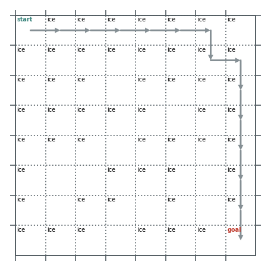

```python
plot(np.zeros_like(Q[:,0]), pi_star_from_Q(Q))
```

Slow converge, but its better!

## Summary

In summary, Monte Carlo RL methods:

- Solution to RF problem
- Require training with complete episodes
- Model free
- Balance in **Exploration vs Exploitation**
- Eventually converge on optimal policy

## References

1. Richard S Sutton and Andrew G Barto. Reinforcement learning: An introduction (second edition). Available online I. MIT press, 2018.
2. Reinforcement Learning 5: Monte Carlo methods https://www.youtube.com/watch?v=4xfWzLmIccs
3. Rohan Sawhney and Keenan Crane. “Monte Carlo geometry processing: a grid-free approach to PDE-based methods on volumetric domains”. In: ACM Transactions on Graphics (TOG) 39.4 (2020), pp. 123–1.